# BIOST/EPI 537 Final Group Project

Geyue Li, Cecilia Martindale, Sarah Garcia

2025-03-08

# 1. Provide an estimate of disease-free survival time for patients enrolled in this study. What are the main characteristics of this summary?

```r
library(survival)
library(survminer)
```

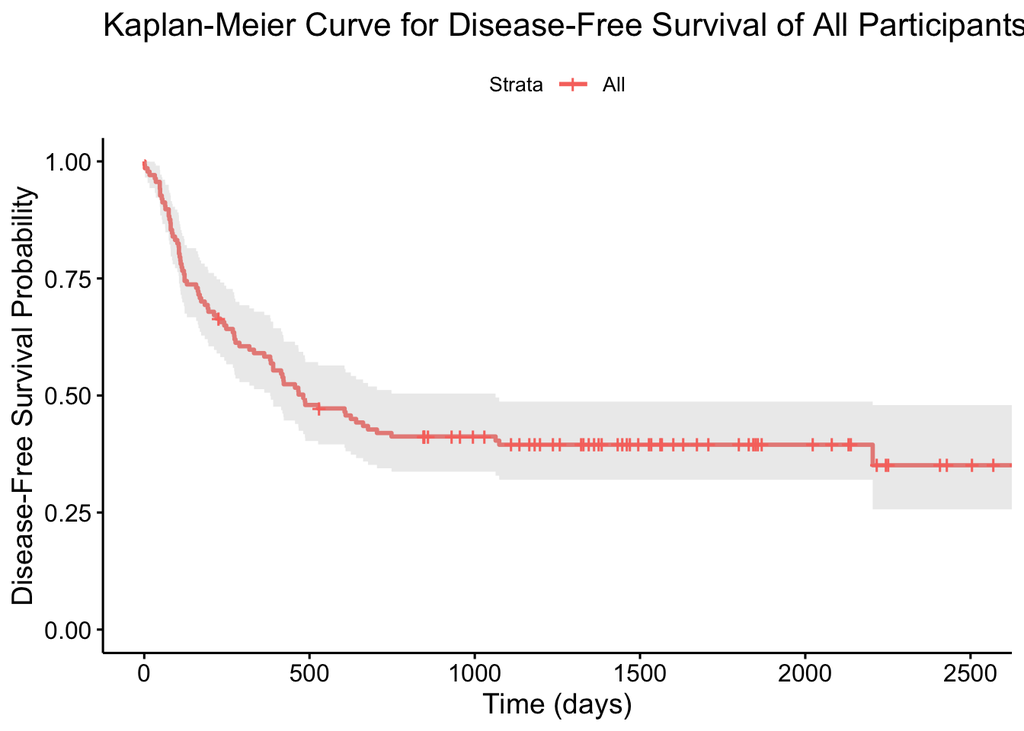

```r
library(ggplot2)
library(dplyr)
library(knitr)
library(broom)
library(table1)
#bmt <- read.csv("~/Documents/UW classes/survival analysis/bmt.csv")
bmt <- read.csv("~/Downloads/bmt.csv")

dfs_surv <- Surv(time = bmt$tdfs, event = bmt$deltadfs)
km_fit <- survfit(dfs_surv ~ 1)

survminer::ggsurvplot(
    fit = km_fit,
    data = bmt,
    conf.int = T,
    xlab = "Time (days)",
    ylab = "Disease-Free Survival Probability",
    title = "Kaplan-Meier Curve for Disease-Free Survival of All Participants"
)
```

```r
summary(km_fit)
```

```
## Call: survfit(formula = dfs_surv ~ 1)
##
##  time n.risk n.event survival std.err lower 95% CI upper 95% CI
##     1    137       1    0.993 0.00727        0.979        1.000
##     2    136       1    0.985 0.01025        0.966        1.000
##    10    135       1    0.978 0.01250        0.954        1.000
##    16    134       1    0.971 0.01438        0.943        0.999
##    32    133       1    0.964 0.01602        0.933        0.995
##    35    132       1    0.956 0.01748        0.923        0.991
##    47    131       2    0.942 0.02003        0.903        0.982
##    48    129       2    0.927 0.02222        0.884        0.972
##    53    127       1    0.920 0.02322        0.875        0.966
##    55    126       1    0.912 0.02415        0.866        0.961
##    63    125       1    0.905 0.02504        0.857        0.956
##    64    124       1    0.898 0.02588        0.848        0.950
```

[output cut: 64 more lines]

# 2. How do patients in different disease groups or in different FAB classifications compare to each other with respect to other available baseline measurements?

```r
baseline_vars <- c("age",  "donorage", "waittime")
cat_vars <- c("male","cmv", "donormale", "donorcmv", "mtx")
# do hospital on its own since it is 4 categories

group_summary <- bmt %>%
  group_by(disgroup) %>%
  summarise(n = n(), across(all_of(baseline_vars), list(mean = mean, sd = sd, median = median), na.rm = TRUE),
            across(all_of(cat_vars), ~ mean(. == 1, na.rm = TRUE) * 100, .names = "percent_{.col}"),
            percent_Ohio=mean(hospital == 1, na.rm = TRUE) * 100,
            percent_Melbourne=mean(hospital == 2, na.rm = TRUE) * 100,
            percent_Sydney=mean(hospital == 3, na.rm = TRUE) * 100,
            percent_Philadelphia=mean(hospital == 4, na.rm = TRUE) * 100) %>%
  mutate(disgroup=case_when(disgroup==1 ~ "ALL",
                            disgroup==2 ~ "Low risk AML",
                            disgroup==3 ~ "High risk AML"))
kable(group_summary, caption = "Baseline Summary by Disease Group (disgroup)")
```

Baseline Summary by Disease Group (disgroup)

| disgroup | n | age_mean | age_sd | age_median | donorage_mean | donorage_sd | donorage_median | waittime_mean | waittime_sd | waittime_median | percent_male | percent_cmv | percent_donormale | percent_donorcmv | percent_mtx | percent_Ohio | percent_Melbourne | percent_Sydney | percent_Philadelphia |
| --- | --- | --- | --- | --- | --- | --- | --- | --- | --- | --- | --- | --- | --- | --- | --- | --- | --- | --- | --- |
| ALL | 38 | 24.42105 | 7.295432 | 22.5 | 26.78947 | 8.932655 | 26.0 | 477.1842 | 598.85625 | 199.5 | 68.42105 | 39.47368 | 68.42105 | 44.73684 | 44.73684 | 55.26316 | 21.052632 | 23.68421 | 0.00000 |
| Low risk AML | 54 | 29.40741 | 8.764247 | 29.5 | 28.07407 | 9.244788 | 29.5 | 138.0556 | 74.48196 | 120.0 | 55.55556 | 48.14815 | 62.96296 | 40.74074 | 22.22222 | 50.00000 | 9.259259 | 12.96296 | 27.77778 |
| High risk AML | 45 | 30.44444 | 11.220022 | 32.0 | 29.93333 | 12.057438 | 29.0 | 268.8667 | 210.70138 | 210.0 | 53.33333 | 60.00000 | 62.22222 | 42.22222 | 24.44444 | 62.22222 | 8.888889 | 15.55556 | 13.33333 |

```r
# Continuous variables - ANOVA or Kruskal-Wallis
kruskal.test(age ~ disgroup, data = bmt)
```

```
##
##  Kruskal-Wallis rank sum test
##
## data:  age by disgroup
## Kruskal-Wallis chi-squared = 10.486, df = 2, p-value = 0.005284
```

```r
kruskal.test(donorage ~ disgroup, data = bmt)
```

```
##
##  Kruskal-Wallis rank sum test
##
## data:  donorage by disgroup
## Kruskal-Wallis chi-squared = 2.4723, df = 2, p-value = 0.2905
```

```r
kruskal.test(waittime ~ disgroup, data = bmt)
```

```
##
##  Kruskal-Wallis rank sum test
##
## data:  waittime by disgroup
## Kruskal-Wallis chi-squared = 26.105, df = 2, p-value = 2.145e-06
```

```r
# Categorical variables - Chi-square test
table_male <- table(bmt$male, bmt$disgroup)
chisq.test(table_male)
```

```
##
##  Pearson's Chi-squared test
##
## data:  table_male
## X-squared = 2.226, df = 2, p-value = 0.3286
```

```r
table_cmv <- table(bmt$cmv, bmt$disgroup)
chisq.test(table_cmv)
```

```
##
##  Pearson's Chi-squared test
##
## data:  table_cmv
## X-squared = 3.5512, df = 2, p-value = 0.1694
```

```r
table_hospital <- table(bmt$hospital, bmt$disgroup)
fisher.test(table_hospital)
```

```
##
##  Fisher's Exact Test for Count Data
##
## data:  table_hospital
## p-value = 0.004719
## alternative hypothesis: two.sided
```

```r
table_mtx <- table(bmt$mtx, bmt$disgroup)
chisq.test(table_mtx)
```

```
##
##  Pearson's Chi-squared test
##
## data:  table_mtx
## X-squared = 6.2014, df = 2, p-value = 0.04502
```

```r
fab_summary <- bmt %>%
  group_by(fab) %>%
  summarise(n = n(), across(all_of(baseline_vars), list(mean = mean, sd = sd, median = median), na.rm = TRUE),
            across(all_of(cat_vars), ~ mean(. == 1, na.rm = TRUE) * 100, .names = "percent_{.col}"),
            percent_Ohio=mean(hospital == 1, na.rm = TRUE) * 100,
            percent_Melbourne=mean(hospital == 2, na.rm = TRUE) * 100,
            percent_Sydney=mean(hospital == 3, na.rm = TRUE) * 100,
            percent_Philadelphia=mean(hospital == 4, na.rm = TRUE) * 100) %>%
  mutate(fab=case_when(fab==0 ~ "Otherwise",
                            fab==1 ~ "FAB Grade 4 or 5 & AML"))

kable(fab_summary, caption = "Baseline Summary by FAB Classification (fab)")
```

Baseline Summary by FAB Classification (fab)

| fab | n | age_mean | age_sd | age_median | donorage_mean | donorage_sd | donorage_median | waittime_mean | waittime_sd | waittime_median | percent_male | percent_cmv | percent_donormale | percent_donorcmv | percent_mtx | percent_Ohio | percent_Melbourne | percent_Sydney | percent_Philadelphia |
| --- | --- | --- | --- | --- | --- | --- | --- | --- | --- | --- | --- | --- | --- | --- | --- | --- | --- | --- | --- |
| Otherwise | 92 | 28.59783 | 9.477631 | 27 | 29.00000 | 9.669256 | 28.5 | 308.7174 | 426.9282 | 180 | 60.86957 | 47.82609 | 63.04348 | 47.82609 | 34.78261 | 52.17391 | 15.217391 | 19.56522 | 13.04348 |
| FAB Grade 4 or 5 & AML | 45 | 27.88889 | 9.810065 | 28 | 26.95556 | 11.133397 | 28.0 | 206.3333 | 163.8541 | 150 | 53.33333 | 53.33333 | 66.66667 | 31.11111 | 17.77778 | 62.22222 | 6.666667 | 11.11111 | 20.00000 |

```r
# Continuous variables - Wilcoxon test (since fab only has 2 levels)
wilcox.test(age ~ fab, data = bmt)
```

```
##
##  Wilcoxon rank sum test with continuity correction
##
## data:  age by fab
## W = 2075.5, p-value = 0.9817
## alternative hypothesis: true location shift is not equal to 0
```

```r
wilcox.test(donorage ~ fab, data = bmt)
```

```
##
##  Wilcoxon rank sum test with continuity correction
##
## data:  donorage by fab
## W = 2212, p-value = 0.5164
## alternative hypothesis: true location shift is not equal to 0
```

```r
wilcox.test(waittime ~ fab, data = bmt)
```

```
##
##  Wilcoxon rank sum test with continuity correction
##
## data:  waittime by fab
## W = 2244.5, p-value = 0.4244
## alternative hypothesis: true location shift is not equal to 0
```

```r
# Categorical variables - Chi-square test
table_male_fab <- table(bmt$male, bmt$fab)
chisq.test(table_male_fab)
```

```
##
##  Pearson's Chi-squared test with Yates' continuity correction
##
## data:  table_male_fab
## X-squared = 0.43028, df = 1, p-value = 0.5119
```

```r
table_cmv_fab <- table(bmt$cmv, bmt$fab)
chisq.test(table_cmv_fab)
```

```
##
##  Pearson's Chi-squared test with Yates' continuity correction
##
## data:  table_cmv_fab
## X-squared = 0.17943, df = 1, p-value = 0.6719
```

```r
table_hospital_fab <- table(bmt$hospital, bmt$fab)
fisher.test(table_hospital_fab)
```

```
##
##  Fisher's Exact Test for Count Data
##
## data:  table_hospital_fab
## p-value = 0.2222
## alternative hypothesis: two.sided
```

```r
table_mtx_fab <- table(bmt$mtx, bmt$fab)
chisq.test(table_mtx_fab)
```

```
##
##  Pearson's Chi-squared test with Yates' continuity correction
##
## data:  table_mtx_fab
## X-squared = 3.4444, df = 1, p-value = 0.06346
```

```r
# table 1
bmt <- bmt %>%
  mutate(disgroupCat = factor(disgroup,
                              levels = c(1, 2, 3),
                              labels = c("All", "Low Risk AML", "High Risk AML")),
         maleCat = factor(male,
                          levels = c(0, 1),
                          labels = c("Female", "Male")),
         cmvCat = factor(cmv,
                         levels = c(0, 1),
                         labels = c("CMV Negative", "CMV Positive")),
         donormaleCat = factor(donormale,
                               levels = c(0, 1),
                               labels = c("Female Donor", "Male Donor")),
         donorcmvCat = factor(donorcmv,
                              levels = c(0, 1),
                              labels = c("CMV Negative Donor", "CMV Positive Donor")),
         fabCat = factor(fab,
                         levels = c(0, 1),
                         labels = c("Otherwise", "FAB Grade 4 or 5 and AML")),
         hospitalCat = factor(hospital,
                              levels = c(1, 2, 3, 4),
                              labels = c("OSU", "Alfred", "St. Vincent", "Hahnemann")),
         mtxCat = factor(mtx,
                         levels = c(0, 1),
                         labels = c("No", "Yes")),
         deltasCat = factor(deltas,
                            levels = c(0, 1),
                            labels = c("Alive", "Dead")),
         deltarCat = factor(deltar,
                            levels = c(0,1),
                            labels = c("Disease-free", "Relapse")),
         deltadfsCat = factor(deltadfs,
                            levels = c(0,1),
                            labels = c("Alive and Disease-free", "Dead or Relapsed")),
         deltaaCat = factor(deltaa,
                            levels = c(0,1),
                            labels = c("No aGVHD", "aGVHD")),
         deltapCat = factor(deltap,
                            levels = c(0,1),
                            labels = c("Not Recovered", "Recovered")))

label(bmt$deltarCat) <- "Replase"
label(bmt$deltasCat) <- "Death"
label(bmt$deltadfsCat) <- "Disease-free Survival"
label(bmt$deltaaCat) <- "aGVHD"
label(bmt$deltapCat) <- "Recovery of Normal Platelet Levels"
label(bmt$age) <- "Patient Age"
label(bmt$maleCat) <- "Patient Sex"
label(bmt$cmvCat) <- "Patient CMV Status"
label(bmt$donorage) <- "Donor Age"
label(bmt$donormaleCat) <- "Donor Sex"
label(bmt$donorcmvCat) <- "Donor CMV Status"
label(bmt$waittime) <- "Wait Time until Transplant (Days)"
label(bmt$fabCat) <- "Disease Subtype"
label(bmt$hospitalCat) <- "Recruitment Center"
label(bmt$mtxCat) <- "Prophylactic Methotrexate Use"

disgroup_tab1 <- table1(~ deltarCat + deltadfsCat + deltaaCat + deltasCat + deltapCat + age + donorage + waittime + maleCat + cmvCat + hospitalCat + mtxCat | disgroupCat,
                        data = bmt,
                        caption = "Baseline Descriptive Statistics by Disease Group")
disgroup_tab1
```

Baseline Descriptive Statistics by Disease Group

|  | All (N=38) | Low Risk AML (N=54) | High Risk AML (N=45) | Overall (N=137) |
| --- | --- | --- | --- | --- |
| Replase |  |  |  |  |
| Disease-free | 26 (68.4%) | 45 (83.3%) | 24 (53.3%) | 95 (69.3%) |
| Relapse | 12 (31.6%) | 9 (16.7%) | 21 (46.7%) | 42 (30.7%) |
| Disease-free Survival |  |  |  |  |
| Alive and Disease-free | 14 (36.8%) | 29 (53.7%) | 11 (24.4%) | 54 (39.4%) |
| Dead or Relapsed | 24 (63.2%) | 25 (46.3%) | 34 (75.6%) | 83 (60.6%) |
| aGVHD |  |  |  |  |
| No aGVHD | 29 (76.3%) | 43 (79.6%) | 39 (86.7%) | 111 (81.0%) |
| aGVHD | 9 (23.7%) | 11 (20.4%) | 6 (13.3%) | 26 (19.0%) |
| Death |  |  |  |  |
| Alive | 14 (36.8%) | 31 (57.4%) | 11 (24.4%) | 56 (40.9%) |
| Dead | 24 (63.2%) | 23 (42.6%) | 34 (75.6%) | 81 (59.1%) |
| Recovery of Normal Platelet Levels |  |  |  |  |
| Not Recovered | 4 (10.5%) | 6 (11.1%) | 7 (15.6%) | 17 (12.4%) |
| Recovered | 34 (89.5%) | 48 (88.9%) | 38 (84.4%) | 120 (87.6%) |
| Patient Age |  |  |  |  |
| Mean (SD) | 24.4 (7.30) | 29.4 (8.76) | 30.4 (11.2) | 28.4 (9.56) |
| Median [Min, Max] | 22.5 [15.0, 42.0] | 29.5 [13.0, 50.0] | 32.0 [7.00, 52.0] | 28.0 [7.00, 52.0] |
| Donor Age |  |  |  |  |
| Mean (SD) | 26.8 (8.93) | 28.1 (9.24) | 29.9 (12.1) | 28.3 (10.2) |
| Median [Min, Max] | 26.0 [5.00, 48.0] | 29.5 [12.0, 54.0] | 29.0 [2.00, 56.0] | 28.0 [2.00, 56.0] |
| Wait Time until Transplant (Days) |  |  |  |  |
| Mean (SD) | 477 (599) | 138 (74.5) | 269 (211) | 275 (365) |
| Median [Min, Max] | 200 [74.0, 2620] | 120 [30.0, 450] | 210 [24.0, 900] | 178 [24.0, 2620] |
| Patient Sex |  |  |  |  |
| Female | 12 (31.6%) | 24 (44.4%) | 21 (46.7%) | 57 (41.6%) |
| Male | 26 (68.4%) | 30 (55.6%) | 24 (53.3%) | 80 (58.4%) |
| Patient CMV Status |  |  |  |  |
| CMV Negative | 23 (60.5%) | 28 (51.9%) | 18 (40.0%) | 69 (50.4%) |
| CMV Positive | 15 (39.5%) | 26 (48.1%) | 27 (60.0%) | 68 (49.6%) |
| Recruitment Center |  |  |  |  |
| OSU | 21 (55.3%) | 27 (50.0%) | 28 (62.2%) | 76 (55.5%) |
| Alfred | 8 (21.1%) | 5 (9.3%) | 4 (8.9%) | 17 (12.4%) |
| St. Vincent | 9 (23.7%) | 7 (13.0%) | 7 (15.6%) | 23 (16.8%) |
| Hahnemann | 0 (0%) | 15 (27.8%) | 6 (13.3%) | 21 (15.3%) |
| Prophylactic Methotrexate Use |  |  |  |  |
| No | 21 (55.3%) | 42 (77.8%) | 34 (75.6%) | 97 (70.8%) |
| Yes | 17 (44.7%) | 12 (22.2%) | 11 (24.4%) | 40 (29.2%) |

```r
fab_tab1 <- table1(~ deltarCat + deltadfsCat + deltaaCat + deltasCat + deltapCat + age + donorage + waittime + maleCat + cmvCat + hospitalCat + mtxCat | fabCat,
                   data = bmt,
                   caption = "Baseline Descriptive Statistics by FAB Classification")
fab_tab1
```

Baseline Descriptive Statistics by FAB Classification

|  | Otherwise (N=92) | FAB Grade 4 or 5 and AML (N=45) | Overall (N=137) |
| --- | --- | --- | --- |
| Replase |  |  |  |
| Disease-free | 72 (78.3%) | 23 (51.1%) | 95 (69.3%) |
| Relapse | 20 (21.7%) | 22 (48.9%) | 42 (30.7%) |
| Disease-free Survival |  |  |  |
| Alive and Disease-free | 44 (47.8%) | 10 (22.2%) | 54 (39.4%) |
| Dead or Relapsed | 48 (52.2%) | 35 (77.8%) | 83 (60.6%) |
| aGVHD |  |  |  |
| No aGVHD | 74 (80.4%) | 37 (82.2%) | 111 (81.0%) |
| aGVHD | 18 (19.6%) | 8 (17.8%) | 26 (19.0%) |
| Death |  |  |  |
| Alive | 45 (48.9%) | 11 (24.4%) | 56 (40.9%) |
| Dead | 47 (51.1%) | 34 (75.6%) | 81 (59.1%) |
| Recovery of Normal Platelet Levels |  |  |  |
| Not Recovered | 12 (13.0%) | 5 (11.1%) | 17 (12.4%) |
| Recovered | 80 (87.0%) | 40 (88.9%) | 120 (87.6%) |
| Patient Age |  |  |  |
| Mean (SD) | 28.6 (9.48) | 27.9 (9.81) | 28.4 (9.56) |
| Median [Min, Max] | 27.0 [13.0, 52.0] | 28.0 [7.00, 50.0] | 28.0 [7.00, 52.0] |
| Donor Age |  |  |  |
| Mean (SD) | 29.0 (9.67) | 27.0 (11.1) | 28.3 (10.2) |
| Median [Min, Max] | 28.5 [5.00, 56.0] | 28.0 [2.00, 48.0] | 28.0 [2.00, 56.0] |
| Wait Time until Transplant (Days) |  |  |  |
| Mean (SD) | 309 (427) | 206 (164) | 275 (365) |
| Median [Min, Max] | 180 [24.0, 2620] | 150 [60.0, 780] | 178 [24.0, 2620] |
| Patient Sex |  |  |  |
| Female | 36 (39.1%) | 21 (46.7%) | 57 (41.6%) |
| Male | 56 (60.9%) | 24 (53.3%) | 80 (58.4%) |
| Patient CMV Status |  |  |  |
| CMV Negative | 48 (52.2%) | 21 (46.7%) | 69 (50.4%) |
| CMV Positive | 44 (47.8%) | 24 (53.3%) | 68 (49.6%) |
| Recruitment Center |  |  |  |
| OSU | 48 (52.2%) | 28 (62.2%) | 76 (55.5%) |
| Alfred | 14 (15.2%) | 3 (6.7%) | 17 (12.4%) |
| St. Vincent | 18 (19.6%) | 5 (11.1%) | 23 (16.8%) |
| Hahnemann | 12 (13.0%) | 9 (20.0%) | 21 (15.3%) |
| Prophylactic Methotrexate Use |  |  |  |
| No | 60 (65.2%) | 37 (82.2%) | 97 (70.8%) |
| Yes | 32 (34.8%) | 8 (17.8%) | 40 (29.2%) |

# 3. Are any of the measured baseline variables associated with differences in disease-free survival?

```r
baseline_vars <- c("age", "male", "cmv", "as.factor(disgroup)",
                   "donorage", "donormale", "donorcmv",
                   "waittime", "as.factor(hospital)", "mtx")

univariate_results <- lapply(baseline_vars, function(var) {
    formula <- as.formula(paste("dfs_surv ~", var))
    cox_model <- coxph(formula, data = bmt)
    result <- tidy(cox_model, conf.int = TRUE, exponentiate=TRUE)  # Ensure confidence intervals are included
    result$variable <- var
    return(result)
})

univariate_results <- do.call(rbind, univariate_results)

colnames(univariate_results)
```

```
## [1] "term"      "estimate"  "std.error" "statistic" "p.value"   "conf.low"
## [7] "conf.high" "variable"
```

```r
univariate_results <- univariate_results[, c("variable", "term", "estimate", "conf.low", "conf.high", "p.value")]

kable(univariate_results, digits = 3, caption = "Univariate Cox Regression Results for Disease-Free Survival")
```

Univariate Cox Regression Results for Disease-Free Survival

| variable | term | estimate | conf.low | conf.high | p.value |
| --- | --- | --- | --- | --- | --- |
| age | age | 1.011 | 0.988 | 1.035 | 0.338 |
| male | male | 0.795 | 0.514 | 1.228 | 0.301 |
| cmv | cmv | 1.167 | 0.759 | 1.796 | 0.482 |
| as.factor(disgroup) | as.factor(disgroup)2 | 0.563 | 0.321 | 0.989 | 0.046 |
| as.factor(disgroup) | as.factor(disgroup)3 | 1.467 | 0.869 | 2.478 | 0.152 |
| donorage | donorage | 1.014 | 0.990 | 1.040 | 0.252 |
| donormale | donormale | 0.991 | 0.633 | 1.552 | 0.970 |
| donorcmv | donorcmv | 1.047 | 0.677 | 1.620 | 0.836 |
| waittime | waittime | 1.000 | 0.999 | 1.001 | 0.791 |
| as.factor(hospital) | as.factor(hospital)2 | 2.122 | 1.148 | 3.922 | 0.016 |
| as.factor(hospital) | as.factor(hospital)3 | 0.912 | 0.495 | 1.681 | 0.768 |
| as.factor(hospital) | as.factor(hospital)4 | 0.421 | 0.191 | 0.930 | 0.032 |
| mtx | mtx | 1.489 | 0.934 | 2.373 | 0.094 |

# 4. It is generally thought that aGVHD has an anti-leukemic effect. Based on the available data, is occurrence of aGVHD after transplantation associated with improved disease-free survival? Is it associated with a decreased risk of relapse? In view of this, do you consider aGVHD as an important prognostic event?

```r
dfs_surv <- Surv(time = bmt$tdfs, event = bmt$deltadfs)

relapse_surv <- Surv(time = bmt$tdfs, event = bmt$deltar)

## univariate Cox for disease-free survival
cox_dfs_unadj <- coxph(dfs_surv ~ deltaa + age + as.factor(hospital) + male, data = bmt)
dfs_summary <- tidy(cox_dfs_unadj, conf.int = TRUE, exponentiate = TRUE)
dfs_summary
```

```
## # A tibble: 6 × 7
##   term                 estimate std.error statistic p.value conf.low conf.high
##   <chr>                   <dbl>     <dbl>     <dbl>   <dbl>    <dbl>     <dbl>
## 1 deltaa                  1.24     0.288      0.742  0.458     0.704     2.18
## 2 age                     1.02     0.0129     1.44   0.150     0.993     1.04
## 3 as.factor(hospital)2    1.88     0.328      1.93   0.0541    0.989     3.58
## 4 as.factor(hospital)3    0.805    0.325     -0.668  0.504     0.425     1.52
## 5 as.factor(hospital)4    0.342    0.423     -2.54   0.0112    0.149     0.783
## 6 male                    0.828    0.234     -0.807  0.419     0.524     1.31
```

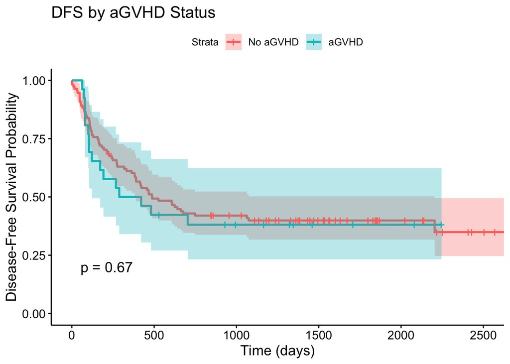

```r
km_dfs <- survfit(dfs_surv ~ deltaa, data = bmt)

ggsurvplot(km_dfs, conf.int = TRUE, pval = TRUE,
           xlab = "Time (days)",
           ylab = "Disease-Free Survival Probability",
           legend.labs = c("No aGVHD", "aGVHD"),
           title = "DFS by aGVHD Status")
```

```r
## multivariable Cox for dfs
cox_dfs_adj <- coxph(dfs_surv ~ deltaa + age + as.factor(hospital) + male, data = bmt)
dfs_summary_adj <- tidy(cox_dfs_adj, conf.int = T, exponentiate = T)
dfs_summary_adj
```

```
## # A tibble: 6 × 7
##   term                 estimate std.error statistic p.value conf.low conf.high
##   <chr>                   <dbl>     <dbl>     <dbl>   <dbl>    <dbl>     <dbl>
## 1 deltaa                  1.24     0.288      0.742  0.458     0.704     2.18
## 2 age                     1.02     0.0129     1.44   0.150     0.993     1.04
## 3 as.factor(hospital)2    1.88     0.328      1.93   0.0541    0.989     3.58
## 4 as.factor(hospital)3    0.805    0.325     -0.668  0.504     0.425     1.52
## 5 as.factor(hospital)4    0.342    0.423     -2.54   0.0112    0.149     0.783
## 6 male                    0.828    0.234     -0.807  0.419     0.524     1.31
```

```r
## univariate Cox for relapse
cox_relapse_unadj <- coxph(relapse_surv ~ deltaa, data = bmt)
relapse_summary <- tidy(cox_relapse_unadj, conf.int = TRUE, exponentiate=TRUE)
relapse_summary
```

```
## # A tibble: 1 × 7
##   term   estimate std.error statistic p.value conf.low conf.high
##   <chr>     <dbl>     <dbl>     <dbl>   <dbl>    <dbl>     <dbl>
## 1 deltaa    0.638     0.477    -0.944   0.345    0.250      1.62
```

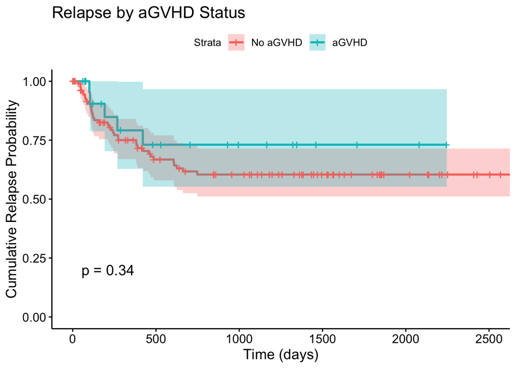

```r
km_relapse <- survfit(relapse_surv ~ deltaa, data = bmt)

ggsurvplot(km_relapse, conf.int = TRUE, pval = TRUE,
           xlab = "Time (days)",
           ylab = "Cumulative Relapse Probability",
           legend.labs = c("No aGVHD", "aGVHD"),
           title = "Relapse by aGVHD Status")
```

```r
## multivariable Cox for relapse
cox_relapse_adj <- coxph(relapse_surv ~ deltaa + age + as.factor(hospital) + male, data = bmt)
relapse_summary_adj <- tidy(cox_relapse_adj, conf.int = T, exponentiate = T)
relapse_summary_adj
```

```
## # A tibble: 6 × 7
##   term                 estimate std.error statistic p.value conf.low conf.high
##   <chr>                   <dbl>     <dbl>     <dbl>   <dbl>    <dbl>     <dbl>
## 1 deltaa                  0.682    0.491     -0.778   0.437    0.260      1.79
## 2 age                     1.01     0.0182     0.587   0.557    0.975      1.05
## 3 as.factor(hospital)2    1.21     0.555      0.350   0.726    0.409      3.60
## 4 as.factor(hospital)3    1.11     0.413      0.243   0.808    0.492      2.48
## 5 as.factor(hospital)4    0.588    0.513     -1.04    0.300    0.215      1.61
## 6 male                    0.673    0.320     -1.24    0.216    0.359      1.26
```

# 5. Among the patients who develop aGVHD, are any of the measured baseline factors associated with differences in disease-free survival?

```r
bmt_agvhd <- subset(bmt, deltaa == 1)

dfs_surv_agvhd <- Surv(time = bmt_agvhd$tdfs, event = bmt_agvhd$deltadfs)

baseline_vars <- c("age", "male", "cmv", "as.factor(disgroup)",
                   "donorage", "donormale", "donorcmv",
                   "waittime", "as.factor(hospital)", "mtx")

uni_agvhd <- lapply(baseline_vars, function(var) {
    formula <- as.formula(paste("dfs_surv_agvhd ~", var))
    cox_model <- coxph(formula, data = bmt_agvhd)
    result <- tidy(cox_model, conf.int = TRUE, exponentiate=TRUE)
    result$variable <- var
    return(result)
})

uni_agvhd <- do.call(rbind, uni_agvhd)

uni_agvhd <- uni_agvhd[, c("variable", "term", "estimate", "conf.low", "conf.high", "p.value")]
kable(uni_agvhd, digits = 3, caption = "Univariate Cox Regression Results for DFS (aGVHD Patients Only)")
```

Univariate Cox Regression Results for DFS (aGVHD Patients Only)

| variable | term | estimate | conf.low | conf.high | p.value |
| --- | --- | --- | --- | --- | --- |
| age | age | 1.024 | 0.978 | 1.073 | 0.307 |
| male | male | 1.323 | 0.478 | 3.661 | 0.590 |
| cmv | cmv | 0.787 | 0.295 | 2.102 | 0.632 |
| as.factor(disgroup) | as.factor(disgroup)2 | 1.450 | 0.424 | 4.966 | 0.554 |
| as.factor(disgroup) | as.factor(disgroup)3 | 3.854 | 1.022 | 14.531 | 0.046 |
| donorage | donorage | 1.072 | 0.996 | 1.153 | 0.063 |
| donormale | donormale | 0.837 | 0.311 | 2.255 | 0.725 |
| donorcmv | donorcmv | 1.878 | 0.647 | 5.453 | 0.247 |
| waittime | waittime | 1.000 | 1.000 | 1.001 | 0.375 |
| as.factor(hospital) | as.factor(hospital)2 | 1.147 | 0.251 | 5.239 | 0.859 |
| as.factor(hospital) | as.factor(hospital)3 | 1.014 | 0.223 | 4.612 | 0.986 |
| as.factor(hospital) | as.factor(hospital)4 | 0.118 | 0.015 | 0.929 | 0.042 |
| mtx | mtx | 1.718 | 0.551 | 5.350 | 0.351 |

# 6. Is prophylactic use of methotrexate associated with an increased or decreased risk of developing aGVHD? Provide an estimate of the survival function of time from transplant until onset of aGVHD separately for patients either administered methotrexate or not. In doing so, consider the importance of accounting for relevant confounding factors.

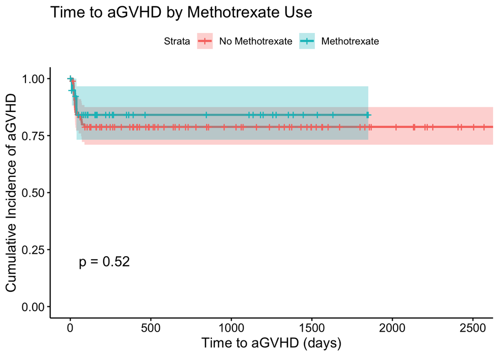

```r
agvhd_surv <- Surv(time = bmt$ta, event = bmt$deltaa)

## unadjusted KM
km_agvhd <- survfit(agvhd_surv ~ mtx, data = bmt)

ggsurvplot(km_agvhd, conf.int = TRUE, pval = TRUE,
           xlab = "Time to aGVHD (days)",
           ylab = "Cumulative Incidence of aGVHD",
           legend.labs = c("No Methotrexate", "Methotrexate"),
           title = "Time to aGVHD by Methotrexate Use")
```

```r
## univariate Cox
cox_mtx <- coxph(agvhd_surv ~ mtx, data = bmt)
univariate_mtx <- tidy(cox_mtx, conf.int = TRUE, exponentiate=TRUE)

kable(univariate_mtx[, c("term", "estimate", "conf.low", "conf.high", "p.value")],
      digits = 3, caption = "Univariate Cox Regression: Methotrexate and aGVHD Risk")
```

Univariate Cox Regression: Methotrexate and aGVHD Risk

| term | estimate | conf.low | conf.high | p.value |
| --- | --- | --- | --- | --- |
| mtx | 0.742 | 0.298 | 1.847 | 0.521 |

```r
## multivariable Cox w/ confounders
cox_adj <- coxph(agvhd_surv ~ mtx + age + male + as.factor(disgroup) + waittime + as.factor(hospital), data = bmt)
multivariable_mtx <- tidy(cox_adj, conf.int = TRUE, exponentiate=TRUE)

kable(multivariable_mtx[, c("term", "estimate", "conf.low", "conf.high", "p.value")],
      digits = 3, caption = "Multivariable Cox Regression: Methotrexate and aGVHD Risk")
```

Multivariable Cox Regression: Methotrexate and aGVHD Risk

| term | estimate | conf.low | conf.high | p.value |
| --- | --- | --- | --- | --- |
| mtx | 0.470 | 0.131 | 1.682 | 0.246 |
| age | 1.074 | 1.027 | 1.123 | 0.002 |
| male | 0.882 | 0.390 | 1.996 | 0.764 |
| as.factor(disgroup)2 | 0.528 | 0.177 | 1.580 | 0.254 |
| as.factor(disgroup)3 | 0.303 | 0.093 | 0.986 | 0.047 |
| waittime | 1.000 | 0.999 | 1.001 | 0.470 |
| as.factor(hospital)2 | 1.632 | 0.316 | 8.417 | 0.558 |
| as.factor(hospital)3 | NA | NA | NA | NA |
| as.factor(hospital)4 | 1.606 | 0.563 | 4.586 | 0.376 |